# Bayesian Logistic Regression Models Comparison: Gambia Malaria Data

Jose Angel Torres.

2024-07-29

### Load the Gambia Malaria data and Data Preparation

```r
# Load and preprocess the Gambia data
data(gambia)
Y <- gambia[,3]
## Y is binary!!!
X <- scale(gambia[,c(4:8)])

#netuse_x_treated <- X[, 2]*X[, 3]
#X$netuse_x_treated <- netuse_x_treated

s <- gambia[,1:2]
n <- length(Y)
S <- unique(s) # Lat/long of the villages
m <- nrow(S)

village <- rep(0, n)
for(j in 1:m){
  d <- (s[,1]-S[j,1])^2 + (s[,2]-S[j,2])^2
  village[d == 0] <- j
}
```

#### For the preprocessing of our data, we separated our responses from our predictors and named them respectively. The presence of NA’s was also checked for and none were found. For this study, coordinates/columns x and y were not used. It is also important to mention that because our data has a target variable that is binary, our approach is a logistic approach. In addition to a logistic approach, we chose three methods pertaining to bayesian statistics; LASSO, RIDGE and SSVS. The response variable chosen is pos, the presence (1) or absence (0) of malaria in a blood sample taken from the child and our predictors are age, netuse, treated, green and phc. We discuss these in greater detail in our presentation.

#### Our study contains the values for WAIC, DIC, AUC, and Bayes Factor. Our goal is to make improvements on the model and see how we can best explain our information and determine which model outperforms the rest in either category. These values will be addressed and compared with the new values we find.

#### It is important to note that all of the data is scaled to reduce bias and compare all models with accuracy.

### Bayesian Logistic Regression

Bayesian logistic regression models the probability of a binary outcome $y_i$ given predictors $X_i$ using a logistic function:
$$P(y_i = 1 \mid X_i, \beta) = \frac{1}{1 + \exp(-X_i \beta)}$$

The posterior distribution of $\beta$ is proportional to the likelihood and the prior:
$$p(\beta \mid y, X) \propto p(y \mid X, \beta) p(\beta)$$

### Bayesian Ridge Logistic Regression

Bayesian Ridge logistic regression includes an L2 norm penalty on the regression coefficients:
$$p(\beta \mid \lambda) \propto \exp\left(-\frac{\lambda}{2} \sum_{j=1}^p
\beta_j^2 \right)$$

### Bayesian Lasso Logistic Regression

Bayesian Lasso logistic regression includes an L1 norm penalty on the regression coefficients:
$$p(\beta \mid \lambda) \propto \exp\left(-\lambda \sum_{j=1}^p |\beta_j|
\right)$$

### Bayesian SSVS Binary Logistic Regression

Bayesian Stochastic Search Variable Selection (SSVS) logistic regression uses spike-and-slab priors to perform variable selection:
$$\beta_j \sim \gamma_j \mathcal{N}(0, \tau_1^2) + (1 - \gamma_j)
\mathcal{N}(0, \tau_0^2)$$

### Polya-Gamma Data Augmentation

The Polya-Gamma data augmentation method for logistic regression replaces the binary response with a continuous latent variable to facilitate Gibbs sampling:
$$\omega_i \mid \beta, y \sim \text{PG}(1, X_i \beta)$$
$$z_i = \frac{y_i - 0.5}{\omega_i}$$
$$\beta \mid \omega, z, X \sim \mathcal{N}(m, V)$$
where $V = (X^T \Omega X + \Sigma^{-1})^{-1}$ and $m = V X^T z$, with $\Omega = \text{diag}(\omega_1, \omega_2, \ldots, \omega_n)$.

### Bayesian SSVS Binary Logistic Regression

```r
ssvs_binary <- function(data, y, x, inprob, runs, burn, progress) {
  x <- data[,x]
  y <- data[,y]

  # Scale inputs
  x <- scale(as.matrix(x))
  y <- as.matrix(y)

  # Make a column of 1s for the design matrix
  intercept <- rep(1, nrow(x))

  # Create design matrix that includes the column of 1s, and the predictors
  designMatrix <- as.matrix(cbind(intercept, x))

  # Save the prior value to use
  myPrior <- BoomSpikeSlab::LogitZellnerPrior(predictors = designMatrix,
                                              successes = y,
                                              trials = NULL,
                                              expected.model.size = (ncol(x)*inprob),
                                              prior.inclusion.probabilities = NULL)

  ## logit.spike()
  if (progress) {
    ping <- runs / 10
  } else {
    ping <- 0
  }
  bssResults <- BoomSpikeSlab::logit.spike(formula = as.matrix(y) ~ as.matrix(x),
                                           niter = runs,
                                           prior = myPrior,
                                           ping = ping)
  bssResults[["beta"]] <- as.data.frame(bssResults[["beta"]][-c(1:burn),-1])

  colnames(bssResults[["beta"]]) <- colnames(x)

  bssResults
}

# Example usage for Gambia data
set.seed(123)
ssvs_results <- ssvs_binary(data = gambia, y = "pos", x = c("age", "netuse", "treated", "green", "phc"), inprob = 0.5, runs = 5000, burn = 1000, progress = TRUE)
```

```
## =-=-=-=-= Iteration 0 Tue Jul 30 01:09:11 2024 =-=-=-=-=
## =-=-=-=-= Iteration 500 Tue Jul 30 01:09:11 2024 =-=-=-=-=
## =-=-=-=-= Iteration 1000 Tue Jul 30 01:09:12 2024 =-=-=-=-=
## =-=-=-=-= Iteration 1500 Tue Jul 30 01:09:12 2024 =-=-=-=-=
## =-=-=-=-= Iteration 2000 Tue Jul 30 01:09:13 2024 =-=-=-=-=
## =-=-=-=-= Iteration 2500 Tue Jul 30 01:09:13 2024 =-=-=-=-=
## =-=-=-=-= Iteration 3000 Tue Jul 30 01:09:14 2024 =-=-=-=-=
## =-=-=-=-= Iteration 3500 Tue Jul 30 01:09:14 2024 =-=-=-=-=
## =-=-=-=-= Iteration 4000 Tue Jul 30 01:09:15 2024 =-=-=-=-=
## =-=-=-=-= Iteration 4500 Tue Jul 30 01:09:15 2024 =-=-=-=-=
```

```r
summary(ssvs_results$beta)
```

```
##       age             netuse            treated             green
##  Min.   :0.0000   Min.   :-0.47964   Min.   :-0.36780   Min.   :0.1191
##  1st Qu.:0.2359   1st Qu.:-0.33116   1st Qu.:-0.09976   1st Qu.:0.2547
##  Median :0.2679   Median :-0.29234   Median : 0.00000   Median :0.2908
##  Mean   :0.2669   Mean   :-0.29082   Mean   :-0.04905   Mean   :0.2886
##  3rd Qu.:0.3008   3rd Qu.:-0.25481   3rd Qu.: 0.00000   3rd Qu.:0.3217
##  Max.   :0.4588   Max.   :-0.06977   Max.   : 0.00000   Max.   :0.4639
##       phc
##  Min.   :-0.269531
##  1st Qu.: 0.000000
##  Median : 0.000000
##  Mean   :-0.018315
##  3rd Qu.: 0.000000
##  Max.   : 0.001398
```

```r
ssvs_samples <- ssvs_results$beta
ssvs_inclusion_prob <- colMeans(ssvs_samples != 0)

selected_variables_ssvs <- which(ssvs_inclusion_prob > 0.5)

# Summarize the marginal distributions of the β_j
beta_summary <- NULL
for (l in 1:ncol(ssvs_samples)) {
  beta_summary <- rbind(beta_summary, cbind(inc_prob = mean(ssvs_samples[, l] != 0),
                                            median = median(ssvs_samples[, l]),
                                            q05 = quantile(ssvs_samples[, l], 0.05),
                                            q95 = quantile(ssvs_samples[, l], 0.95)))
}
colnames(beta_summary) <- c("Inclusion Probability", "Median", "5%", "95%")
rownames(beta_summary) <- colnames(ssvs_samples)
kable(round(beta_summary, 2))
```

|  | Inclusion Probability | Median | 5% | 95% |
| --- | --- | --- | --- | --- |
| age | 1.00 | 0.27 | 0.18 | 0.34 |
| netuse | 1.00 | -0.29 | -0.38 | -0.19 |
| treated | 0.27 | 0.00 | -0.23 | 0.00 |
| green | 1.00 | 0.29 | 0.20 | 0.37 |
| phc | 0.13 | 0.00 | -0.16 | 0.00 |

```r
# Compute the posterior probability of each model
model_list <- apply(ssvs_samples != 0, 1, function(row) {
  paste("Intercept", paste(names(which(row)), collapse = " + "))
})
model_probs <- table(model_list) / length(model_list)
model_probs_df <- data.frame(Model = names(model_probs), Posterior_Probability = as.numeric(model_probs))
model_probs_df <- model_probs_df[order(model_probs_df$Posterior_Probability, decreasing = TRUE), ]
kable(model_probs_df[1:5, ], col.names = c("Model", "Posterior Probability"))
```

|  | Model | Posterior Probability |
| --- | --- | --- |
| 1 | Intercept age + netuse + green | 0.60675 |
| 3 | Intercept age + netuse + treated + green | 0.26675 |
| 2 | Intercept age + netuse + green + phc | 0.12450 |
| 4 | Intercept age + netuse + treated + green + phc | 0.00175 |
| 5 | Intercept netuse + green | 0.00025 |

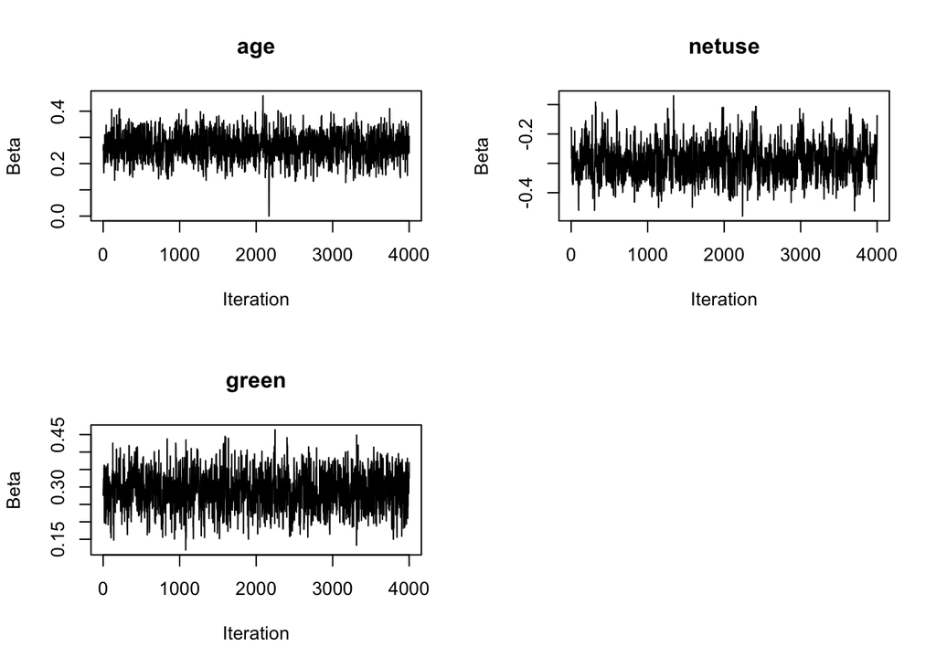

```r
# Traceplot for Bayesian SSVS
if (length(selected_variables_ssvs) > 0) {
  par(mfrow = c(2, 2))
  for (i in selected_variables_ssvs) {
    plot(ssvs_samples[, i], type = "l", main = colnames(X)[i], ylab = "Beta", xlab = "Iteration")
  }
}

#Histogram for Bayesian SSVS
par(mfrow = c(2, 2))
```

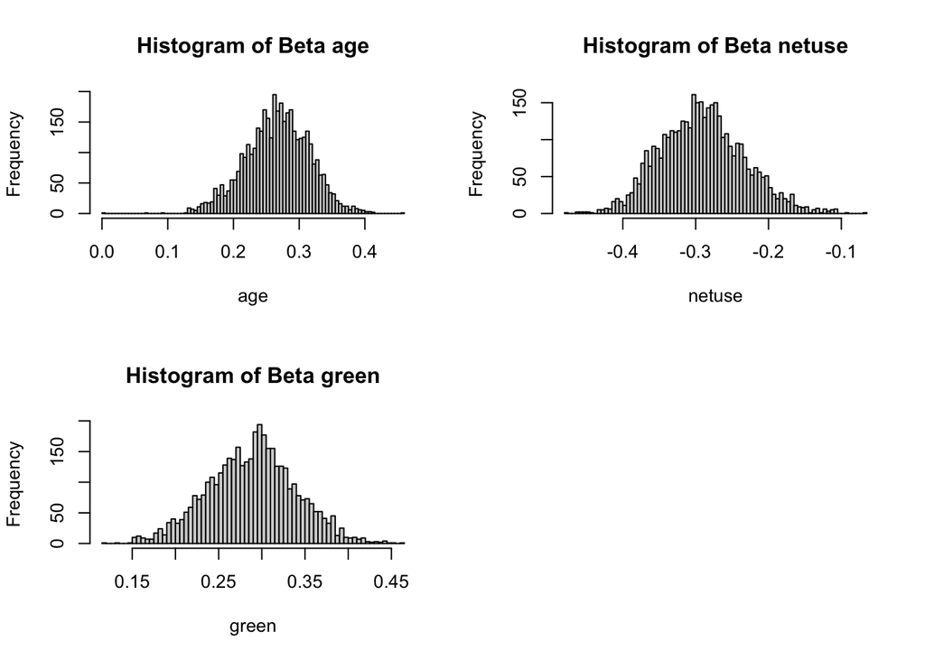

```r
for (i in selected_variables_ssvs) {
  hist(ssvs_samples[, i], main = paste("Histogram of Beta", colnames(ssvs_samples)[i]), xlab = colnames(ssvs_samples)[i], breaks = 100)
}
```

#### Traceplots were put in place for variables deemed significant and at 4000 iterations, convergence was tested. Our plot appear thick and centers around a constant mean.

#### The histograms for our significant betas show clear peaks at approximately 0.26, -0.3 and 0.30 respectively expressing the precision we need for a powerful model.

### Bayesian Ridge Logistic Regression

```r
bayesian_ridge_logistic <- function(y, X, iterations = 5000, burn_in = 1000) {

  n <- length(y)
  p <- ncol(X)
  beta <- matrix(0, nrow = iterations, ncol = p)
  sigma2 <- 1
  tau2 <- 1
  for (i in 2:iterations) {
    # Sample beta
    Sigma_beta <- solve(t(X) %*% X + diag(1/tau2, p, p))
    mu_beta <- Sigma_beta %*% t(X) %*% y
    beta[i, ] <- mvrnorm(1, mu = mu_beta, Sigma = Sigma_beta)
    # Sample sigma2
    sigma2 <- 1 / rgamma(1, shape = n/2, rate = sum((y - X %*% beta[i, ])^2)/2)
    # Sample tau2
    tau2 <- 1 / rgamma(1, shape = p/2, rate = sum(beta[i, ]^2)/2)
  }
  beta <- beta[-c(1:burn_in), ]
  return(beta)
}

# Example usage
ridge_results <- bayesian_ridge_logistic(Y, X)
summary(ridge_results)
```

```
##        V1                 V2                 V3                  V4
##  Min.   :-0.02181   Min.   :-0.12590   Min.   :-0.110689   Min.   :-0.02290
##  1st Qu.: 0.03292   1st Qu.:-0.06327   1st Qu.:-0.038850   1st Qu.: 0.03631
##  Median : 0.04671   Median :-0.04779   Median :-0.023703   Median : 0.05117
##  Mean   : 0.04710   Mean   :-0.04875   Mean   :-0.024050   Mean   : 0.05107
##  3rd Qu.: 0.06142   3rd Qu.:-0.03334   3rd Qu.:-0.009152   3rd Qu.: 0.06561
##  Max.   : 0.12884   Max.   : 0.02084   Max.   : 0.073175   Max.   : 0.12322
##        V5
##  Min.   :-0.093404
##  1st Qu.:-0.031531
##  Median :-0.017136
##  Mean   :-0.017431
##  3rd Qu.:-0.003371
##  Max.   : 0.060365
```

```r
#Intervals
ridge_cred_int <- apply(ridge_results, 2, quantile, probs = c(0.05, 0.95))

# Criteria
selected_variables <- which(apply(ridge_cred_int, 2, function(x) sign(x[1]) == sign(x[2])))
selected_variables_ridge <- colnames(X)[selected_variables]
selected_variables_ridge
```

```
## [1] "age"    "netuse" "green"
```

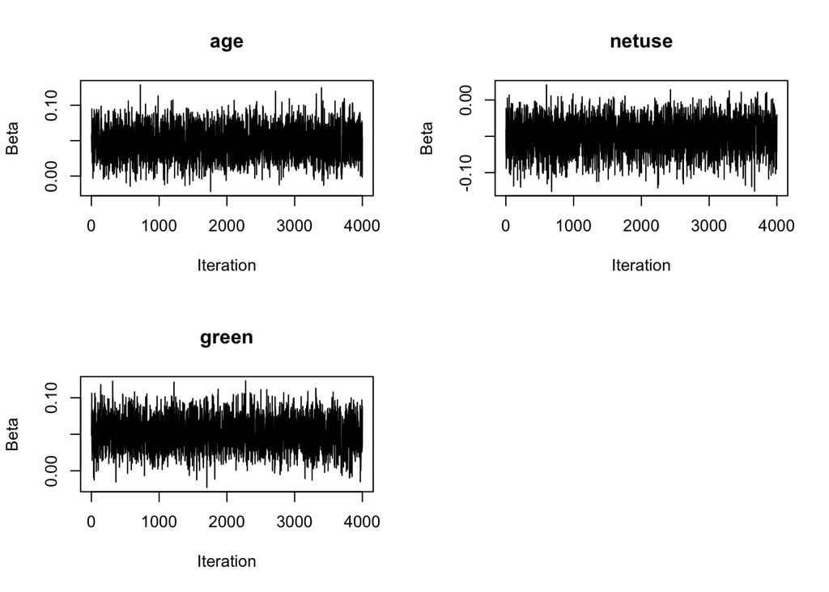

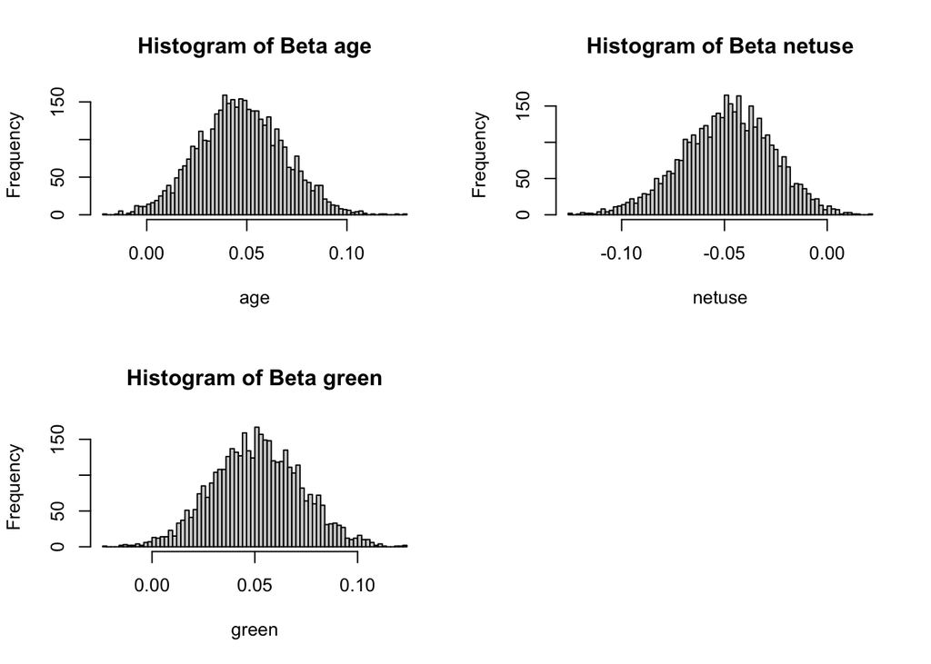

```r
# Traceplots for Bayesian Ridge
if (length(selected_variables_ridge) > 0) {
  par(mfrow = c(2, 2))
  for (i in selected_variables) {
    plot(ridge_results[, i], type = "l", main = colnames(X)[i], ylab = "Beta", xlab = "Iteration")
  }
}


# Histogram for Bayesian Ridge
if (length(selected_variables_ridge) > 0) {
  par(mfrow = c(2, 2))
  for (i in selected_variables) {
    hist(ridge_results[, i], main = paste("Histogram of Beta", colnames(X)[i]), xlab = colnames(X)[i], breaks = 100)
  }
}
```

#### For Bayesian Ridge, tau, sigma, and lambda were used and played with but little to no change was discovered. Once again, the decrease in runs is where most of our insight is from. The process for determining significant betas stays the same in ridge with the exception of inclusion probabilities. Our interval is the same here with 90% of our information being captured this time. The condition in place for determining significant betas is looking for the intervals of all our predictor values and identify those with the same sign. Once again the values that were chosen were age netuse and green.

#### Our traceplot provides us with dense plots indicating convergence and are tested against 4000 iterations as before.

#### For ridge, our histograms peaked at around .04, -.05 and 05 respectively.

### Bayesian Lasso Logistic Regression

```r
bayesian_lasso_logistic <- function(y, X, iterations = 5000, burn_in = 1000, lambda = 1) {
  n <- length(y)
  p <- ncol(X)
  beta <- matrix(0, nrow = iterations, ncol = p)
  tau <- rep(1, p)
  for (i in 2:iterations) {
    # Sample beta
    Sigma_beta <- solve(t(X) %*% X + diag(1/tau, p, p))
    mu_beta <- Sigma_beta %*% t(X) %*% y
    beta[i, ] <- mvrnorm(1, mu = mu_beta, Sigma = Sigma_beta)
    # Sample tau
    for (j in 1:p) {
      tau[j] <- 1 / rgamma(1, shape = 1 + lambda, rate = abs(beta[i, j]) + lambda)
    }
  }
  beta <- beta[-c(1:burn_in), ]
  return(beta)
}

# Example usage
lasso_results <- bayesian_lasso_logistic(Y, X)
summary(lasso_results)
```

```
##        V1                 V2                 V3                  V4
##  Min.   :-0.02615   Min.   :-0.15304   Min.   :-0.125975   Min.   :-0.03215
##  1st Qu.: 0.04312   1st Qu.:-0.07563   1st Qu.:-0.044335   1st Qu.: 0.04645
##  Median : 0.05804   Median :-0.05897   Median :-0.024677   Median : 0.06250
##  Mean   : 0.05858   Mean   :-0.05885   Mean   :-0.025291   Mean   : 0.06183
##  3rd Qu.: 0.07417   3rd Qu.:-0.04248   3rd Qu.:-0.006446   3rd Qu.: 0.07712
##  Max.   : 0.13580   Max.   : 0.04534   Max.   : 0.058176   Max.   : 0.13859
##        V5
##  Min.   :-0.133385
##  1st Qu.:-0.038351
##  Median :-0.022210
##  Mean   :-0.021891
##  3rd Qu.:-0.005374
##  Max.   : 0.061868
```

```r
# Intervals
lasso_cred_int <- apply(lasso_results, 2, quantile, probs = c(0.05, 0.95))

# Criteria
selected_variables <- which(apply(lasso_cred_int, 2, function(x) sign(x[1]) == sign(x[2])))
selected_variables_lasso <- colnames(X)[selected_variables]
selected_variables_lasso
```

```
## [1] "age"    "netuse" "green"
```

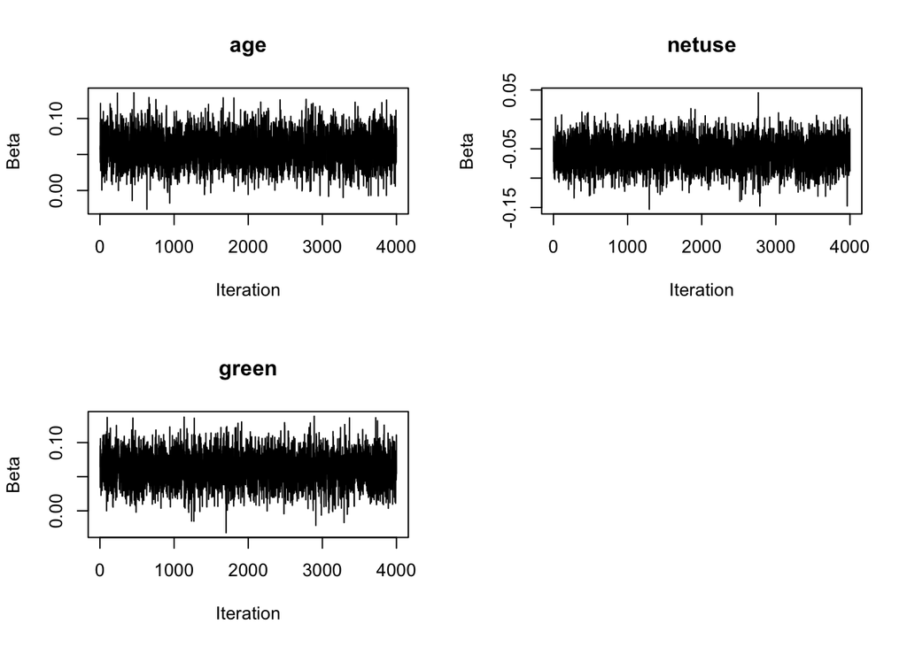

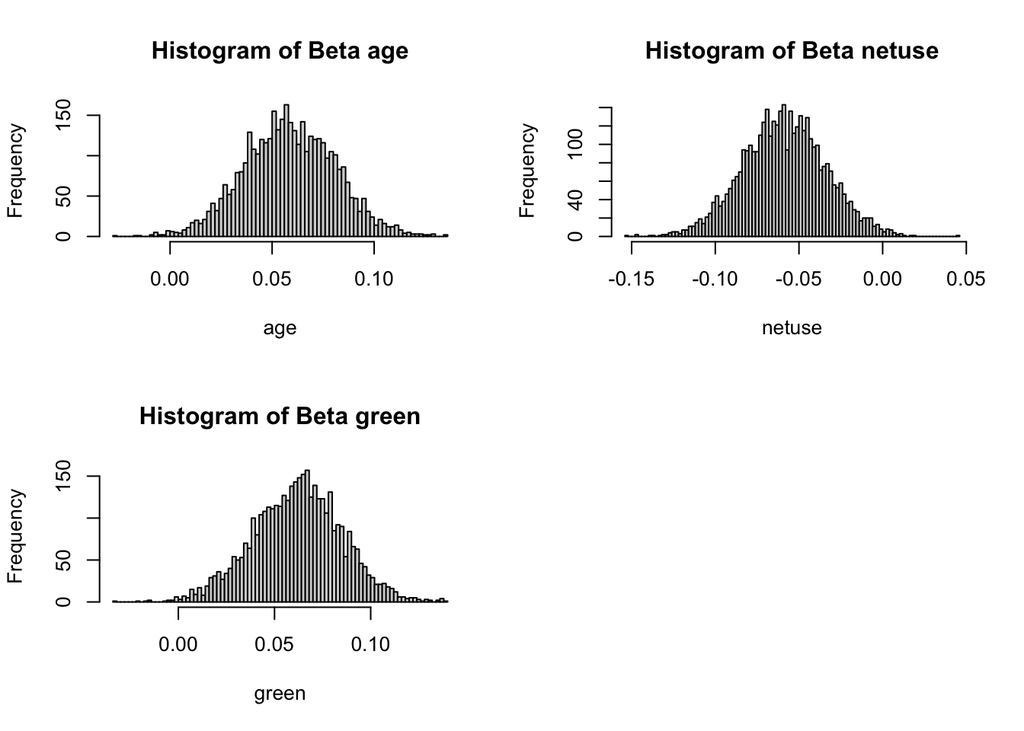

```r
# Traceplots for Bayesian Lasso
if (length(selected_variables_lasso) > 0) {
  par(mfrow = c(2, 2))
  for (i in selected_variables) {
    plot(lasso_results[, i], type = "l", main = colnames(X)[i], ylab = "Beta", xlab = "Iteration")
  }
}

# Histograms for Bayesian Lasso
if (length(selected_variables_lasso) > 0) {
  par(mfrow = c(2, 2))
  for (i in selected_variables) {
    hist(lasso_results[, i], main = paste("Histogram of Beta", colnames(X)[i]), xlab = colnames(X)[i], breaks = 100)
  }
}
```

#### For Bayesian Lasso, sigma, and lambda were used and played with but little to no change was discovered. Once again, the decrease in runs is where most of our insight is from. The process for determining significant betas stays the same in lasso with the exception of inclusion probabilities. Our interval is the same here with 90% of our information being captured this time. The condition in place for determining significant betas is looking for the intervals of all our predictor values and identify those with the same sign. Once again the values that were chosen were age netuse and green.

#### Our traceplot provides us with dense plots indicating convergence and are tested against 4000 iterations. None of the traceplots differed too much from one another across the different methods. We can be picky and choose ssvs as the plot being outperformed by lasso and ridge slightly but there really isnt much of a difference among them.

#### For lasso, our histograms peaked at around .06, -.07 and 07 respectively.

### 5-Fold Cross-Validation and AUC Comparison

```r
library(caret)
```

```r
set.seed(123)

# Prepare data for 5-fold cross-validation
folds <- createFolds(Y, k = 5, list = TRUE)

# Function to calculate AUC for model predictions
calculate_auc <- function(actual, predicted) {
  roc_curve <- roc(actual, predicted)
  auc <- auc(roc_curve)
  return(auc)
}

# Initialize vectors to store AUC values
auc_ssvs <- c()
auc_ridge <- c()
auc_lasso <- c()

# Cross-validation
for (fold in folds) {

  train_indices <- setdiff(seq_len(nrow(gambia)), fold)
  test_indices <- fold

  X_train <- X[train_indices, ]
  Y_train <- Y[train_indices]
  X_test <- X[test_indices, ]
  Y_test <- Y[test_indices]

  # SSVS model
  ssvs_model <- ssvs_binary(data = gambia[train_indices, ], y = "pos", x = c("age", "netuse", "treated", "green", "phc"), inprob = 0.5, runs = 5000, burn = 1000, progress = FALSE)
  ssvs_beta <- colMeans(ssvs_model$beta)
  ssvs_pred <- plogis(X_test %*% ssvs_beta)
  auc_ssvs <- c(auc_ssvs, calculate_auc(Y_test, ssvs_pred))

  # Bayesian Ridge model
  ridge_model <- bayesian_ridge_logistic(Y_train, X_train)
  ridge_beta <- colMeans(ridge_model)
  ridge_pred <- plogis(X_test %*% ridge_beta)
  auc_ridge <- c(auc_ridge, calculate_auc(Y_test, ridge_pred))

  # Bayesian Lasso model
  lasso_model <- bayesian_lasso_logistic(Y_train, X_train)
  lasso_beta <- colMeans(lasso_model)
  lasso_pred <- plogis(X_test %*% lasso_beta)
  auc_lasso <- c(auc_lasso, calculate_auc(Y_test, lasso_pred))
}
# Output AUC values
cat("5-Fold Cross-Validation AUC Results:\n")
```

```
## 5-Fold Cross-Validation AUC Results:
```

```r
cat("SSVS Model AUC:", mean(auc_ssvs), "\n")
```

```
## SSVS Model AUC: 0.638687
```

```r
cat("Bayesian Ridge Model AUC:", mean(auc_ridge), "\n")
```

```
## Bayesian Ridge Model AUC: 0.648103
```

```r
cat("Bayesian Lasso Model AUC:", mean(auc_lasso), "\n")
```

```
## Bayesian Lasso Model AUC: 0.6475795
```

#### Note: 5 fold cross validation is implemented into the calculation of AUC. The dataset is divided into 5 equally sized folds where k = 5 folds are trained and tested. k-1 = 4 folds are used as training while the remaining fold is used as testing. This is done k = 5 times making sure every fold has been trained and tested.

### DIC and WAIC

```r
# Function to compute log likelihood
log_lik <- function(beta, X, y) {
  p <- plogis(X %*% beta)
  return(dbinom(y, size = 1, prob = p, log = TRUE))
}

# Function to compute DIC and WAIC
compute_dic_waic <- function(samples, X, y) {
  log_lik_values <- apply(samples, 1, function(beta) log_lik(beta, X, y))

  # Compute DIC
  pD <- mean(apply(log_lik_values, 2, var)) / 2
  DIC <- -2 * mean(apply(log_lik_values, 1, sum)) + 2 * pD

  # Compute WAIC
  waic_res <- waic(log_lik_values)

  list(DIC = DIC, WAIC = waic_res$waic)
}

# Compute DIC and WAIC for each model
dic_waic_ridge <- compute_dic_waic(ridge_results, X, Y)
dic_waic_lasso <- compute_dic_waic(lasso_results, X, Y)
dic_waic_ssvs <- compute_dic_waic(ssvs_results$beta, X, Y)
cat("DIC and WAIC for Ridge Model:\n")
```

```
## DIC and WAIC for Ridge Model:
```

```r
print(dic_waic_ridge)
```

```
## $DIC
## [1] 5455.988
##
## $WAIC
## [1] 5467.799
```

```r
cat("DIC and WAIC for Lasso Model:\n")
```

```
## DIC and WAIC for Lasso Model:
```

```r
print(dic_waic_lasso)
```

```
## $DIC
## [1] 5440.466
##
## $WAIC
## [1] 5456.988
```

```r
cat("DIC and WAIC for SSVS Model:\n")
```

```
## DIC and WAIC for SSVS Model:
```

```r
print(dic_waic_ssvs)
```

```
## $DIC
## [1] 5318.72
##
## $WAIC
## [1] 5606.883
```

#### Here our criteria showed the most change after tuning our model. Previously, our ridge had a dic of 12275.45 and a waic of 12302.13. lasso had a dic 12241.15 of and a waic of 12278.23. ssvs had a dic 11967.79 of and a waic of 12606.29. The model that performed the best was ssvs for DIC and lasso for WAIC

#### After tuning, our ridge had a dic of 5455.988 and a waic of 5467.799. lasso had a dic 5440.466 of and a waic of 5456.988. ssvs had a dic 5318.72 of and a waic of 5606.883. Although all of our values decreased, The models that performed the best were still ssvs for DIC and lasso for WAIC once again

### Bayes Factor

```r
# Function to compute Bayes Factor using Savage-Dickey density ratio method
compute_bayes_factor <- function(samples1, samples2) {
  posterior1 <- density(samples1)
  posterior2 <- density(samples2)

  prior1 <- dnorm(0, mean = mean(samples1), sd = sd(samples1))
  prior2 <- dnorm(0, mean = mean(samples2), sd = sd(samples2))

  posterior_density_ratio <- approxfun(posterior1)(0) / approxfun(posterior2)(0)
  prior_density_ratio <- prior1 / prior2

  bf <- posterior_density_ratio / prior_density_ratio
  bf
}

# Compute Bayes Factor for each pair of models
bayes_factor_ridge_lasso <- compute_bayes_factor(ridge_results[,1], lasso_results[,1])
bayes_factor_ridge_ssvs <- compute_bayes_factor(ridge_results[,1], ssvs_results$beta[,1])
bayes_factor_lasso_ssvs <- compute_bayes_factor(lasso_results[,1], ssvs_results$beta[,1])

cat("Bayes Factor (Ridge vs Lasso):", bayes_factor_ridge_lasso, "\n")
```

```
## Bayes Factor (Ridge vs Lasso): 1.007337
```

```r
cat("Bayes Factor (Ridge vs SSVS):", bayes_factor_ridge_ssvs, "\n")
```

```
## Bayes Factor (Ridge vs SSVS): 0.0001698073
```

```r
cat("Bayes Factor (Lasso vs SSVS):", bayes_factor_lasso_ssvs, "\n")
```

```
## Bayes Factor (Lasso vs SSVS): 0.0001685704
```

### Fixing NA Errors in Bayes Factor Calculations

To address the NA errors in Bayes Factor calculations, we can implement a check to ensure that the densities are properly evaluated at zero. Here’s the updated `compute_bayes_factor` function:

```r
compute_bayes_factor <- function(samples1, samples2) {
  posterior1 <- density(samples1)
  posterior2 <- density(samples2)

  posterior_density1 <- approxfun(posterior1)(0)
  posterior_density2 <- approxfun(posterior2)(0)

  prior1 <- dnorm(0, mean = mean(samples1), sd = sd(samples1))
  prior2 <- dnorm(0, mean = mean(samples2), sd = sd(samples2))

  if (is.na(posterior_density1) || is.na(posterior_density2)) {
    return(Inf)
  }

  posterior_density_ratio <- posterior_density1 / posterior_density2
  prior_density_ratio <- prior1 / prior2

  bf <- posterior_density_ratio / prior_density_ratio
  bf
}

# Recompute Bayes Factor for each pair of models
bayes_factor_ridge_lasso <- compute_bayes_factor(ridge_results[,1], lasso_results[,1])
bayes_factor_ridge_ssvs <- compute_bayes_factor(ridge_results[,1], ssvs_results$beta[,1])
bayes_factor_lasso_ssvs <- compute_bayes_factor(lasso_results[,1], ssvs_results$beta[,1])

cat("Bayes Factor (Ridge vs Lasso):", bayes_factor_ridge_lasso, "\n")
```

```
## Bayes Factor (Ridge vs Lasso): 1.007337
```

```r
cat("Bayes Factor (Ridge vs SSVS):", bayes_factor_ridge_ssvs, "\n")
```

```
## Bayes Factor (Ridge vs SSVS): 0.0001698073
```

```r
cat("Bayes Factor (Lasso vs SSVS):", bayes_factor_lasso_ssvs, "\n")
```

```
## Bayes Factor (Lasso vs SSVS): 0.0001685704
```

#### Numerator vs Denominator = N/D

#### Our Bayes factor for ridge vs lasso at 1.007337 leans slightly in the direction of ridge but is not strong enough to indicate whether lasso outperforms ridge.

#### Our Bayes factor for ridge vs ssvs is much closer to 0 at 0.0001698073 supporting ssvs over ridge

#### Our Bayes factor for lasso vs ssvs is much closer to 0 at 0.0001685704 supporting ssvs over lasso

#### for bayes factor, the model that performed the best is ssvs.

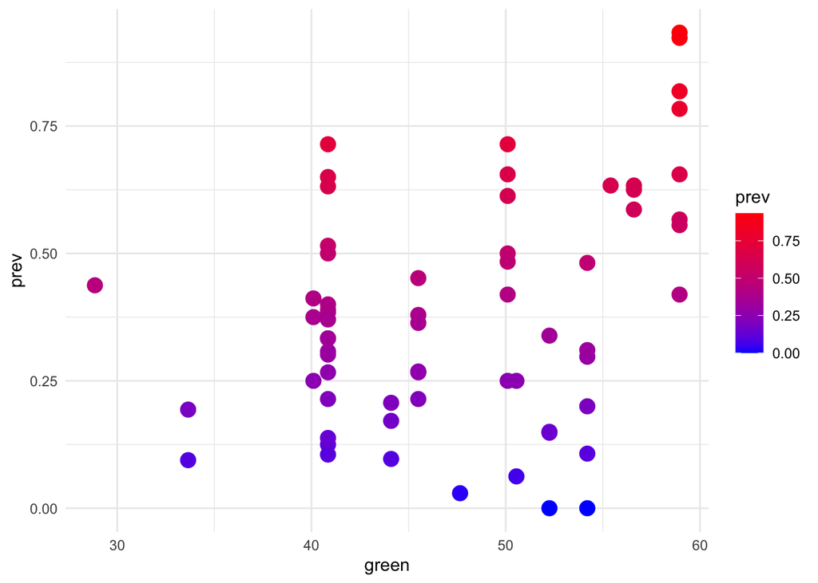

```r
ind <- paste("x",gambia[,1], "y", gambia[,2], sep="")
village <- gambia[!duplicated(ind),c(1:2,7:8)]
village$prev <- as.vector(tapply(gambia$pos, ind, mean))

ggplot(village, aes(x = green, y = prev, color = prev)) +
  geom_point(size = 4) +
  scale_color_gradient(low = "blue", high = "red") +
  theme_minimal()
```

#### A scatterplot was created using the x and y coordinates in the gambia dataset to see how the average presence of malaria or “prevalance” was seen in villages as we approach green-ness of vegitation

#### Some of the limitations that were introduced very early in this study involved tuning. Several attempts gave us slight changes but never in the right direction. It was only when iterations dropped that progress was finally made. The presence of as many as 10000 iterations likely caused overfitting and would not let our model accurately represent any of the information given. To overcome this as the increase of iterations caused worse results, smaller runs were used and caused our models dic and waic to decrease significantly; this appeared to alleviate the computational intensity the model mustve been going through to constantly iterate information. Another technique that was attempted but not used was the setting of an interaction term. The interaction between netuse and treated appeared to have some relevance when combined but this would have to wait for further testing as erros would not allow me to continue.

#### We used slightly different methods for determining if a covariate is significant; all 3 models each had their pros and cons.

#### Lasso does a great job indicating variables that are deemed insignificant and unlike ridge will remove variables as soon as a beta coefficient reaches 0. A con to this is given we only have 5 predictors, we have to be careful what variables we remove. The weight these variables have with less predictors can unintentionally have a negative impact on our results

#### Ridge is similar to lasso but does not allow our beta coefficients to reach 0 precisely. This can be beneficial to us in a model like this because we dont have too many predictors to begin with. A pro would be its ability to overcome issues like overfitting. Luckily for ridge we have a condition in place to remove variables for us other than the usual penalties. Both lasso and ridge are probably easier computationally but not as easy to interpret.

#### ssvs has the most unique and interprettable approach as it looks for inclusion probabilities for our reponse variable(pos) when there is a presence of malaria in blood samples of children. It looks for those with coefficients not equal to zero and intervals allowing us to see in which direction our predictors influence our response. A pro in ssvs is our ability to understand what our uncertainty looks like in the model and provide probabilistic estimates of important variables and relevant parameters. This is demonstrated nicely in the posterior probability and histogram above. A con of ssvs can be how computationally intensive it can be as well as determining which prior to use. We can evaluate these different priors in further studies.

#### The Bayesian ridge logistic regression performs the best in terms of the 5-fold CV AUC, but the Bayesian ssvs is preferred by the Bayes Factor.

#### For DIC, Bayesian ssvs performed best and for WAIC Bayesian lasso logistic regression performed best

#### The Bayesian ridge logistic regression, Bayesian Lasso logistic regression and Bayesian SSVS all selected only 3 variables: age, netuse, and green.

#### One important thing to note is that of all the histograms, ssvs contained the highest range of beta coefficients. They suggested that age and green impacted the results of malaria positively and netuse impacted it negatively greater than any other model. Although the models themselves excelled in varying criteria, the impact ssvs suggests these predictors had on the pos can certainly be looked into for further analysis.